# POX-C Supplement

Wills et al

March 12, 2018

## POX-C Project Analysis

#### Load Data

This will download relevent data for this project from a NRCS file sharing site.

```r
# POX (AC) sample pool used to select samples for further
# analysis
AC_url <- "https://nrcs.box.com/shared/static/bm9o3nj55rstbsvoloysid75pcxf3tlr.csv"
ifelse(!file.exists("ACsamplelist.csv"), download.file(AC_url,
    destfile = paste0("ACsamplelist.csv")), "File already downloaded")
```

```
# [1] "File already downloaded"
```

```r
# POX (AC) samples selected for further analysis
ACselect_url <- "https://nrcs.box.com/shared/static/wll2xi6v73b1f9re6t7mlhpl8afha4oe.csv"
ifelse(!file.exists("ACsampleselect.csv"), download.file(ACselect_url,
    destfile = paste0("ACsampleselect.csv")), "File already downloaded")
```

```
# [1] "File already downloaded"
```

```r
# Newly analyzed data, for this project
POX_url <- "https://nrcs.box.com/shared/static/t9antdnnt502sa1x8a7qu5r7n3z4yk7v.csv"
ifelse(!file.exists("pox_project_data.csv"), download.file(POX_url,
    destfile = paste0("pox_project_data.csv")), "File already downloaded")
```

```
# [1] "File already downloaded"
```

```r
# other information about project samples
POX_info_url <- "https://nrcs.box.com/shared/static/7ke7l4ob2rmw3zoqf16pm6a5m9qpoo5y.csv"
ifelse(!file.exists("pox_project_info.csv"), download.file(POX_info_url,
    destfile = paste0("pox_project_info.csv")), "File already downloaded")
```

```
# [1] "File already downloaded"
```

### Select samples

This portion of the anlysis cannot be replicated so it is not rerun each time. It is included to show how the samples were selected from the available KSSL samples at the time of analysis.

```r
# all KSSL samples with available POXC measurements,
# auxiliary data and available sample
AClist <- read.csv("ACsamplelist.csv")

AClist$taxonomic.order <- as.factor(toupper(AClist$taxonomic.order))

levels(AClist$taxonomic.order)  #standardize categorical variable
```

```
#  [1] ""            "ALFISOLS"    "ANDISOLS"    "ARIDISOLS"   "ENTISOLS"
#  [6] "HISTOSOLS"   "INCEPTISOLS" "MOLLISOLS"   "ULTISOLS"    "VERTISOLS"
```

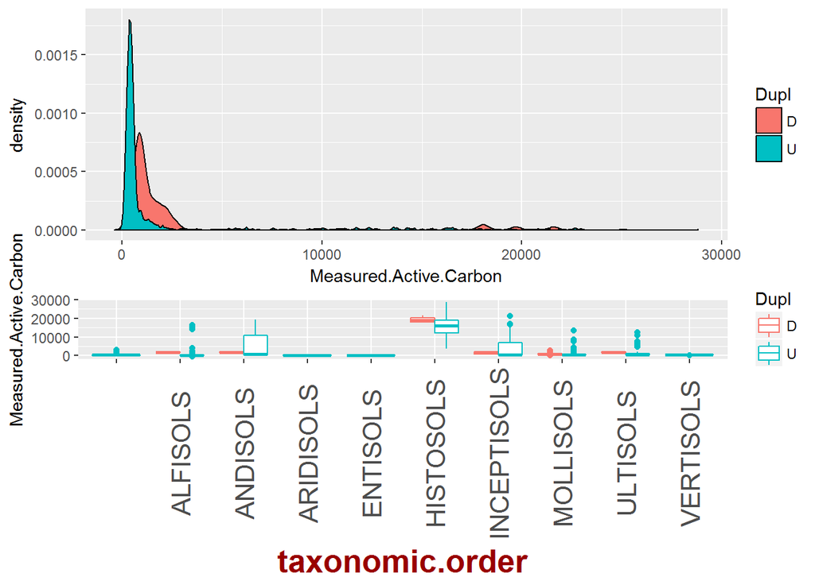

```r
# visualize duplicated samples - the values seem to change
# when they've been run more than once
D <- ggplot(data = AClist, aes(x = Measured.Active.Carbon, fill = Dupl)) +
    geom_density()


dd <- ggplot(data = AClist, aes(y = Measured.Active.Carbon, x = taxonomic.order,
    color = Dupl)) + geom_boxplot() + theme(axis.title.x = element_text(face = "bold",
    colour = "#990000", size = 20), axis.text.x = element_text(angle = 90,
    vjust = 0.5, size = 16))

grid.arrange(D, dd)
```

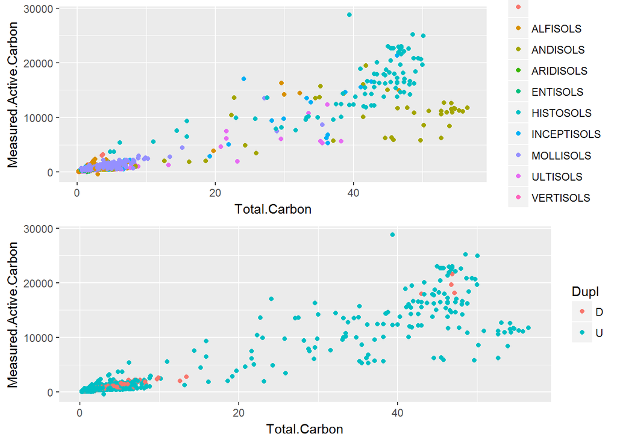

```r
tC <- ggplot(data = AClist, aes(x = Total.Carbon, y = Measured.Active.Carbon,
    color = taxonomic.order)) + geom_point()
tCt <- ggplot(data = AClist, aes(x = Total.Carbon, y = Measured.Active.Carbon,
    color = Dupl)) + geom_point()

grid.arrange(tC, tCt)
```

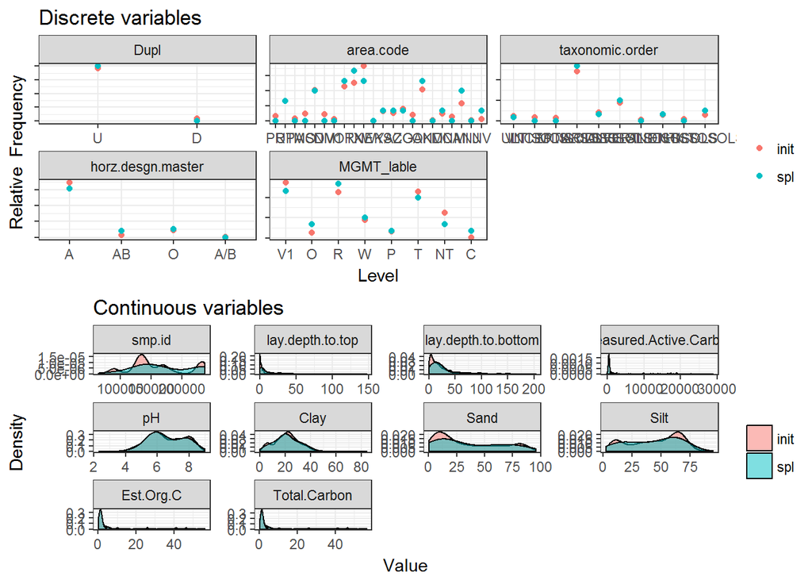

```r
# include all variable including smp.id - which is assigned
# chrnologically as a proxy for time of analysis
res <- clhs(AClist, size = 30, iter = 1000, progress = FALSE,
    simple = FALSE)

plot(res, modes = "dens")
```

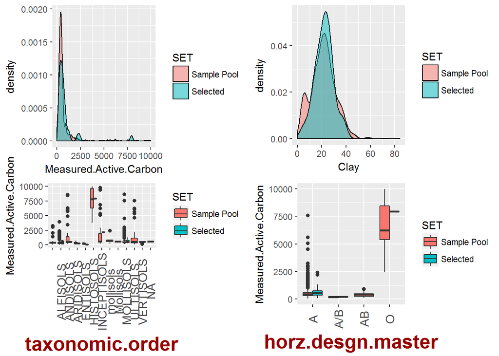

```r
# output selected samples for futher analysis
samp <- res$sampled_data
# write.csv(samp, 'ACsamp_select.csv')

# use the actual selection list
samp <- read_csv("ACsampleselect.csv")

# evaluate selection more specifically

# Add a value to ID both sets
samp <- samp %>% mutate(SET = "Selected", smp.id = as.factor(smp.id))
AClist <- AClist %>% mutate(SET = "Sample Pool", smp.id = as.factor(smp.id))

sampAC <- bind_rows(samp, AClist) %>% rename(MGMT = MGMT_lable)

S <- ggplot(data = sampAC, aes(x = Measured.Active.Carbon)) +
    geom_density(aes(fill = SET), alpha = 0.5) + scale_x_continuous(limits = c(0,
    10000))
Scl <- ggplot(data = sampAC, aes(x = Clay)) + geom_density(aes(fill = SET),
    alpha = 0.5)


Sd <- ggplot(data = sampAC, aes(y = Measured.Active.Carbon, x = taxonomic.order)) +
    geom_boxplot(aes(fill = SET)) + theme(axis.title.x = element_text(face = "bold",
    colour = "#990000", size = 20), axis.text.x = element_text(angle = 90,
    vjust = 0.5, size = 12)) + scale_y_continuous(limits = c(0,
    10000))


Sc <- ggplot(data = sampAC, aes(y = Measured.Active.Carbon, x = horz.desgn.master)) +
    geom_boxplot(aes(fill = SET)) + theme(axis.title.x = element_text(face = "bold",
    colour = "#990000", size = 20), axis.text.x = element_text(angle = 90,
    vjust = 0.5, size = 12)) + scale_y_continuous(limits = c(0,
    10000))

grid.arrange(S, Scl, Sd, Sc, ncol = 2)
```

```r
rm(AClist, res, samp, sampAC, tC, tCt, Sd, Sc)
```

#### Prepare Meausred Data for analysis

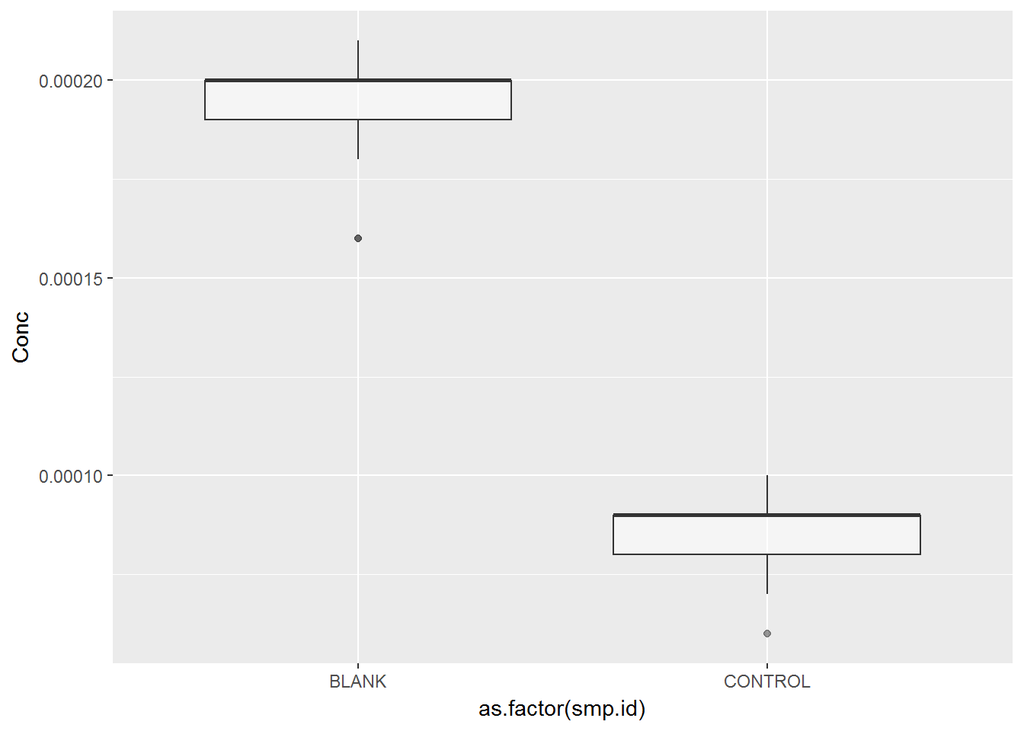

```r
POX_info <- read.csv("pox_project_info.csv")

POX <- read.csv("pox_project_data.csv")

# ID blank and control
cb <- c("1", "168")
CB <- c("BLANK", "CONTROL")

POX$smp.id <- as.factor(ifelse(POX$smp_id == 1, "BLANK", ifelse(POX$smp_id ==
    168, "CONTROL", as.character(POX$smp_id))))

# evaluate blanks and checks
ggplot(POX[POX$smp.id == CB, ], aes(y = Conc, x = as.factor(smp.id))) +
    geom_boxplot(alpha = 0.5)
```

```r
POX.cb.summ <- POX %>% filter(smp.id == CB) %>% group_by(smp.id) %>%
    summarize(N.conc = length(Conc), mean.conc = mean(Conc, na.rm = TRUE),
        sd.conc = sd(Conc, na.rm = TRUE), se.conc = sd.conc/sqrt(N.conc),
        CV.conc = sd.conc/mean.conc, N.pox = length(AC), mean.pox = mean(AC,
            na.rm = TRUE), sd.pox = sd(AC, na.rm = TRUE), se.pox = sd.pox/sqrt(N.pox),
        CV.pox = sd.pox/mean.pox)

POX.cb.summ
```

```
# # A tibble: 2 x 11
#   smp.id  N.conc mean.conc  sd.conc  se.conc CV.conc N.pox mean.pox sd.pox
#   <fct>    <int>     <dbl>    <dbl>    <dbl>   <dbl> <int>    <dbl>  <dbl>
# 1 BLANK       84 0.000195   7.68e-6  8.38e-7  0.0394    84      NaN  NaN
# 2 CONTROL     84 0.0000858  8.95e-6  9.76e-7  0.104     84      822   64.3
# # ... with 2 more variables: se.pox <dbl>, CV.pox <dbl>
```

```r
# information about selected samples (remove blanks and
# controls)
POX <- POX[!(grepl("BLANK", POX$smp.id) | grepl("CONTROL", POX$smp.id)) |
    !(grepl("", POX$Validation)), ]

POX <- droplevels.data.frame(POX)

# treat sample amount/weight as a class
POX$wt_class <- factor(POX$wt_class)

# treat preparation/grind as facors and relabel
POX$Grind <- factor(POX$Grind, levels = c("lt2mm", "fine_lt80um"),
    labels = c("< 2 mm Grind", "Fine Grind"))
```

#### Eploratory Data Analysis

First, both the mean and standard deviation of each sample is calculated (from 3 replicates). Then a summary table is produced by Grind and Weight.

```r
# summary by sample
POX.smp.summ <- POX %>% filter(smp.id != CB, !is.na(wt_class)) %>%
    mutate(Weight = wt_class) %>% group_by(smp.id, Grind, Weight) %>%
    summarize(Clay = mean(Clay), Total.Carbon = mean(Total.Carbon),
        pH = mean(pH_H2O), N.conc = length(Conc), mean.conc = mean(Conc,
            na.rm = TRUE), sd.conc = sd(Conc, na.rm = TRUE),
        se.conc = sd.conc/sqrt(N.conc), CV.conc = sd.conc/mean.conc,
        N.pox = length(AC), mean.pox = mean(AC, na.rm = TRUE),
        sd.pox = sd(AC, na.rm = TRUE), se.pox = sd.pox/sqrt(N.pox),
        CV.pox = sd.pox/mean.pox, Concentration = mean.conc,
        POX = mean.pox)


# summary by amount and grind
POX.summ <- POX.smp.summ %>% group_by(Grind, Weight) %>% summarize(N.conc = length(mean.conc),
    mean.conc = mean(mean.conc, na.rm = TRUE), avg.sd.conc = mean(sd.conc,
        na.rm = TRUE), avg.se.conc = mean(se.conc, na.rm = TRUE),
    avg.CV.conc = mean(CV.conc, na.rm = TRUE), N.pox = length(mean.pox),
    mean.pox = mean(mean.pox, na.rm = TRUE), avg.sd.pox = mean(sd.pox,
        na.rm = TRUE), avg.se.pox = mean(se.pox, na.rm = TRUE),
    avg.CV.pox = mean(CV.pox, na.rm = TRUE), Concentration = mean.conc,
    POX = mean.pox)

kable(POX.summ %>% select(Concentration, Weight, Grind) %>% spread(Weight,
    Concentration), digits = 5, align = "c", caption = "Average Solution Concentration \n by Grind size and Analyzed Weight")
```

Average Solution Concentration by Grind size and Analyzed Weight

| Grind | 0.25 | 0.5 | 1 | 2.5 | 5 |
| --- | --- | --- | --- | --- | --- |
| < 2 mm Grind | 0.00018 | 0.00017 | 0.00015 | 0.00011 | 6e-05 |
| Fine Grind | 0.00017 | 0.00015 | 0.00013 | 0.00007 | 3e-05 |

```r
kable(POX.summ %>% select(Grind, Weight, POX) %>% spread(Weight,
    POX), digits = 1, align = "c", caption = "Average POX C \n by Grind size and Analyzed Weight")
```

Average POX C by Grind size and Analyzed Weight

| Grind | 0.25 | 0.5 | 1 | 2.5 | 5 |
| --- | --- | --- | --- | --- | --- |
| < 2 mm Grind | 1606.1 | 1157.2 | 919.7 | 695.7 | 509.5 |
| Fine Grind | 2194.7 | 1743.2 | 1370.7 | 933.2 | 611.9 |

```r
kable(POX.summ %>% select(Grind, Weight, avg.sd.pox) %>% spread(Weight,
    avg.sd.pox), digits = 2, align = "c", caption = "SD of POX \n Average by Grind size and Analyzed Weight")
```

SD of POX Average by Grind size and Analyzed Weight

| Grind | 0.25 | 0.5 | 1 | 2.5 | 5 |
| --- | --- | --- | --- | --- | --- |
| < 2 mm Grind | 189.02 | 110.02 | 62.61 | 34.52 | 11.68 |
| Fine Grind | 198.13 | 100.39 | 54.76 | 20.60 | 8.21 |

```r
# library(kableExtra) kable(POX.summ %>% select(Grind,
# Weight, Concentration, POX), 'html') %>%
# kable_styling(boostrap_options = c('striped', 'hover'))
```

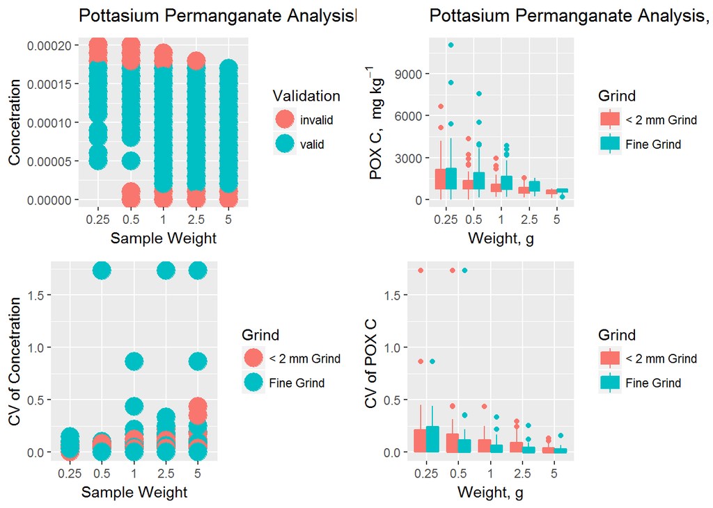

```r
a <- POX %>% ggplot(aes(y = Conc, x = wt_class, color = Validation)) +
    geom_point(size = 6) + labs(x = "Sample Weight", y = "Concetration",
    title = expression(paste("Pottasium Permanganate Analysis",
        "KMnO"[4])))


b <- POX.smp.summ %>% ggplot(aes(y = POX, x = Weight, color = Grind)) +
    geom_boxplot(aes(fill = Grind)) + labs(x = "Weight, g", y = expression(paste("POX C, ",
    " mg kg"^-1)), title = expression(paste("Pottasium Permanganate Analysis,  ",
    "KMnO"[4])))

c <- POX.smp.summ %>% ggplot(aes(y = CV.conc, x = Weight, color = Grind)) +
    geom_point(size = 6) + labs(x = "Sample Weight", y = "CV of Concetration")


d <- POX.smp.summ %>% ggplot(aes(y = CV.pox, x = Weight, color = Grind)) +
    geom_boxplot(aes(fill = Grind)) + labs(x = "Weight, g", y = "CV of POX C ")

grid.arrange(a, b, c, d, ncol = 2, top = expression(paste("Pottasium Permanganate Analysis",
    "KMnO"[4])))
```

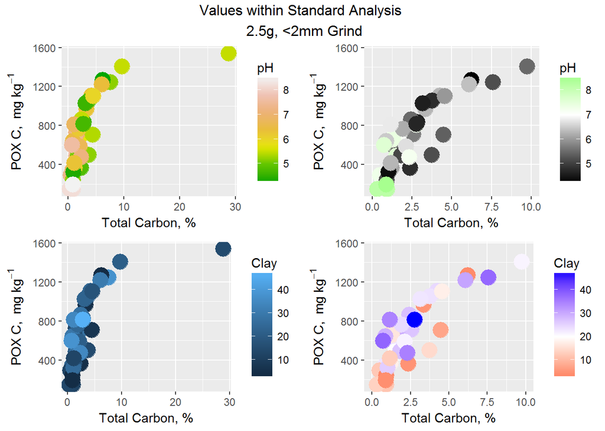

```r
e <- POX.smp.summ %>% filter(Weight == "2.5" & Grind == "< 2 mm Grind") %>%
    ggplot(aes(y = POX, x = Total.Carbon)) + geom_point(aes(color = pH),
    size = 6) + labs(x = "Total Carbon, %", y = expression(paste("POX C, ",
    " mg kg"^-1))) + scale_color_gradientn(colours = terrain.colors(7))

f <- e + scale_x_continuous(limits = c(0, 10)) + scale_color_gradient2(low = "black",
    mid = "white", high = "green", midpoint = 7)


g <- POX.smp.summ %>% filter(Weight == "2.5" & Grind == "< 2 mm Grind") %>%
    ggplot(aes(y = POX, x = Total.Carbon)) + geom_point(aes(color = Clay),
    size = 6) + labs(x = "Total Carbon, %", y = expression(paste("POX C, ",
    " mg kg"^-1)))

h <- g + scale_x_continuous(limits = c(0, 10)) + scale_color_gradient2(low = "red",
    mid = "white", high = "blue", midpoint = 20)

grid.arrange(e, f, g, h, ncol = 2, top = "Values within Standard Analysis \n 2.5g, <2mm Grind")
```

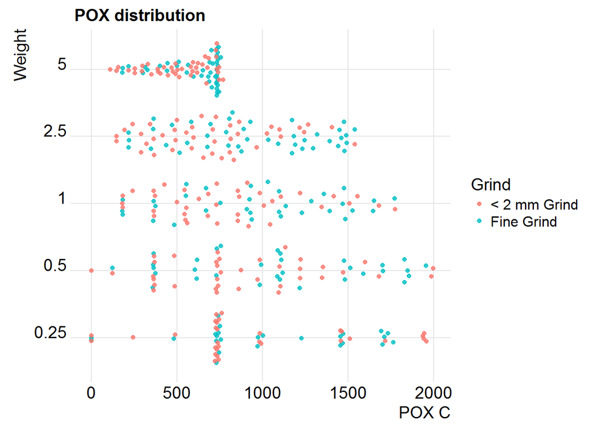

```r
B <- POX.smp.summ %>% ggplot(aes(x = POX, y = Weight, color = Grind)) +
    geom_quasirandom(alpha = 0.82, groupOnX = FALSE) + theme_joy() +
    scale_x_continuous(limits = c(0, 2000)) + labs(x = "POX C",
    y = "Weight", title = "POX distribution")

B
```

```r
rm(a, b, c, d, e, f, g, h, B)
```

## Measured POX with other variables

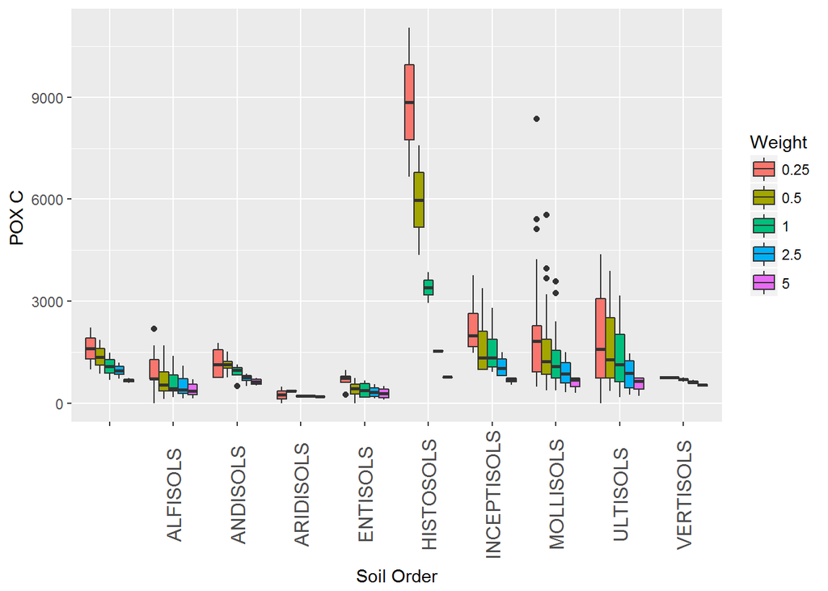

```r
POX.info <- POX.smp.summ %>% left_join(POX_info %>% mutate(smp.id = as.factor(smp.id)),
    by = "smp.id") %>% mutate(Order = toupper(Order)) %>% rename(Master = horz.desgn.master)

i <- POX.info %>% ggplot(aes(y = POX, x = Order)) + geom_boxplot(aes(fill = Weight)) +
    labs(x = "Soil Order", y = "POX C ") + theme(axis.text.x = element_text(angle = 90,
    vjust = 0.5, size = 12))

j <- POX.info %>% ggplot(aes(y = POX, x = Master)) + geom_boxplot(aes(fill = Grind)) +
    labs(x = "Master Horizon", y = "POX C ") + theme(axis.text.x = element_text(angle = 90,
    vjust = 0.5, size = 12))

i
```

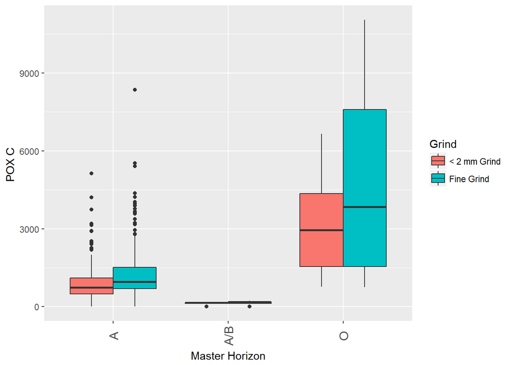

```r
j
```

```r
rm(POX_info, i, j)
```

### ANOVA

Graphical inspection indicates that both sample size and grind impact POX measurements. A more formal analysis to detect differences - Treating weights as a class (they are not random); balanced factorial means that the type of ANOVA test done isn’t critical. A general linearized model is to determine the significane of of specific main effects (Weight and Grind) and interactions.

Orders and Master horizon may need to be evaluated - though it may be more likely that removing organics will deal with any issue. And the relationships are very similar

```r
a <- aov(POX ~ Grind + Weight + Grind * Weight, data = POX.smp.summ)
summary(a)
```

```
#               Df    Sum Sq  Mean Sq F value   Pr(>F)
# Grind          1  16225268 16225268  14.735 0.000143 ***
# Weight         4  93254273 23313568  21.173 6.92e-16 ***
# Grind:Weight   4   3938787   984697   0.894 0.467281
# Residuals    410 451459895  1101122
# ---
# Signif. codes:  0 '***' 0.001 '**' 0.01 '*' 0.05 '.' 0.1 ' ' 1
```

```r
at <- glm(POX ~ Grind + Weight + Grind * Weight, data = POX.smp.summ)
summary(at, correlation = TRUE, symbolic.cor = TRUE)
```

```
#
# Call:
# glm(formula = POX ~ Grind + Weight + Grind * Weight, data = POX.smp.summ)
#
# Deviance Residuals:
#     Min       1Q   Median       3Q      Max
# -2194.7   -491.7    -62.1    189.1   8853.3
#
# Coefficients:
#                            Estimate Std. Error t value Pr(>|t|)
# (Intercept)                1606.127    161.917   9.919  < 2e-16 ***
# GrindFine Grind             588.571    228.986   2.570  0.01051 *
# Weight0.5                  -448.968    228.986  -1.961  0.05059 .
# Weight1                    -686.444    228.986  -2.998  0.00289 **
# Weight2.5                  -910.389    228.986  -3.976 8.29e-05 ***
# Weight5                   -1096.587    228.986  -4.789 2.35e-06 ***
# GrindFine Grind:Weight0.5    -2.484    323.834  -0.008  0.99388
# GrindFine Grind:Weight1    -137.563    323.834  -0.425  0.67121
# GrindFine Grind:Weight2.5  -351.095    323.834  -1.084  0.27892
# GrindFine Grind:Weight5    -486.222    323.834  -1.501  0.13401
# ---
# Signif. codes:  0 '***' 0.001 '**' 0.01 '*' 0.05 '.' 0.1 ' ' 1
#
# (Dispersion parameter for gaussian family taken to be 1101122)
#
#     Null deviance: 564878224  on 419  degrees of freedom
# Residual deviance: 451459895  on 410  degrees of freedom
# AIC: 7046.8
#
# Number of Fisher Scoring iterations: 2
#
# Correlation of Coefficients:
#
# (Intercept)               1
# GrindFine Grind           , 1
# Weight0.5                 , . 1
# Weight1                   , . . 1
# Weight2.5                 , . . . 1
# Weight5                   , . . . . 1
# GrindFine Grind:Weight0.5 . , , . . . 1
# GrindFine Grind:Weight1   . , . , . . . 1
# GrindFine Grind:Weight2.5 . , . . , . . . 1
# GrindFine Grind:Weight5   . , . . . , . . . 1
# attr(,"legend")
# [1] 0 ' ' 0.3 '.' 0.6 ',' 0.8 '+' 0.9 '*' 0.95 'B' 1
```

```r
anova(at)
```

```
# Analysis of Deviance Table
#
# Model: gaussian, link: identity
#
# Response: POX
#
# Terms added sequentially (first to last)
#
#
#              Df Deviance Resid. Df Resid. Dev
# NULL                           419  564878224
# Grind         1 16225268       418  548652956
# Weight        4 93254273       414  455398683
# Grind:Weight  4  3938787       410  451459895
```

```r
# might add mixed model with Order and Master and variables

# without Histosols



a.h <- aov(POX ~ Grind + Weight + Grind * Weight, data = POX.info %>%
    filter(Order != "HISTOSOLS"))
summary(a.h)
```

```
#               Df    Sum Sq  Mean Sq F value   Pr(>F)
# Grind          1  13372587 13372587  18.580 2.05e-05 ***
# Weight         4  69187625 17296906  24.033  < 2e-16 ***
# Grind:Weight   4   2655561   663890   0.922    0.451
# Residuals    400 287888012   719720
# ---
# Signif. codes:  0 '***' 0.001 '**' 0.01 '*' 0.05 '.' 0.1 ' ' 1
```

### DSP POXC values

load data from DSP projects DSP_master <- https://nrcs.box.com/shared/static/e53czbbenk8cjfg4tp4hmvxtm2vnprn4.xlsx loook at quantiles and evalauate high - med - low